# Harvardx Capstone Project 2

Daisuke Ohnuki

6/16/2021

## Introduction

### Load libraries

```r
# We will install libraries for our analysis and modeling.
knitr::opts_chunk$set(echo = TRUE, warning = FALSE)
if(!require(tidyverse)) install.packages("tidyverse", repos = "http://cran.us.r-project.org")
```

```
## ─ Attaching packages ──────────────────── tidyverse 1.3.0 ─
```

```
## ─ Conflicts ───────────────────── tidyverse_conflicts() ─
```

```r
if(!require(e1071)) install.packages("e1071", repos = "http://cran.us.r-project.org")
if(!require(randomForest)) install.packages("randomForest", repos = "http://cran.us.r-project.org")
if(!require(rsample)) install.packages("rsample", repos = "http://cran.us.r-project.org")
if(!require(tinytex)) install.packages("tinytex", repos = "http://cran.us.r-project.org")
if(!require(data.table)) install.packages("data.table", repos = "http://cran.us.r-project.org")
if(!require(caret)) install.packages("caret", repos = "http://cran.us.r-project.org")
```

```r
if(!require(ggplot2)) install.packages("ggplot2", repos = "http://cran.us.r-project.org")
if(!require(corrplot)) install.packages("corrplot", repos = "http://cran.us.r-project.org")
if(!require(latexpdf)) install.packages("latexpdf", repos = "http://cran.us.r-project.org")
library(dplyr)
library(tidyverse)
library(tinytex)
library(e1071)
library(randomForest)
library(rsample)
library(data.table)
library(caret)
library(ggplot2)
library(corrplot)
library(latexpdf)
```

### Data setting

Then we set the data. We download the dataset, “heart_failure_clinical_records_dataset.csv”, from the Kaggle site. The data is provided by Larxel.

```r
# Dawnload the dataset from the website;
#https://www.kaggle.com/andrewmvd/heart-failure-clinical-data  The data is provided by Larxel.
data<- read.csv ("heart_failure_clinical_records_dataset.csv",
                 header = TRUE)
```

### Summary of the dataset

```r
#We can see the summary of the dataset.
#The data set has 299 rows with 13 variables.
summary(data)
```

```
##       age           anaemia       creatinine_phosphokinase    diabetes
##  Min.   :40.00   Min.   :0.0000   Min.   :  23.0           Min.   :0.0000
##  1st Qu.:51.00   1st Qu.:0.0000   1st Qu.: 116.5           1st Qu.:0.0000
##  Median :60.00   Median :0.0000   Median : 250.0           Median :0.0000
##  Mean   :60.83   Mean   :0.4314   Mean   : 581.8           Mean   :0.4181
##  3rd Qu.:70.00   3rd Qu.:1.0000   3rd Qu.: 582.0           3rd Qu.:1.0000
##  Max.   :95.00   Max.   :1.0000   Max.   :7861.0           Max.   :1.0000
##  ejection_fraction high_blood_pressure   platelets      serum_creatinine
##  Min.   :14.00     Min.   :0.0000      Min.   : 25100   Min.   :0.500
##  1st Qu.:30.00     1st Qu.:0.0000      1st Qu.:212500   1st Qu.:0.900
##  Median :38.00     Median :0.0000      Median :262000   Median :1.100
##  Mean   :38.08     Mean   :0.3512      Mean   :263358   Mean   :1.394
##  3rd Qu.:45.00     3rd Qu.:1.0000      3rd Qu.:303500   3rd Qu.:1.400
##  Max.   :80.00     Max.   :1.0000      Max.   :850000   Max.   :9.400
##   serum_sodium        sex            smoking            time
##  Min.   :113.0   Min.   :0.0000   Min.   :0.0000   Min.   :  4.0
##  1st Qu.:134.0   1st Qu.:0.0000   1st Qu.:0.0000   1st Qu.: 73.0
##  Median :137.0   Median :1.0000   Median :0.0000   Median :115.0
##  Mean   :136.6   Mean   :0.6488   Mean   :0.3211   Mean   :130.3
##  3rd Qu.:140.0   3rd Qu.:1.0000   3rd Qu.:1.0000   3rd Qu.:203.0
##  Max.   :148.0   Max.   :1.0000   Max.   :1.0000   Max.   :285.0
##   DEATH_EVENT
##  Min.   :0.0000
##  1st Qu.:0.0000
##  Median :0.0000
##  Mean   :0.3211
##  3rd Qu.:1.0000
##  Max.   :1.0000
```

### Explanation of the variables

The DEATH_EVENT variables will be the dependent variable. 1.age = Age of patient

2.anaemia = Decrease of red blood cells or hemoglobin (0=False, 1=True)

3.creatinine_phosphokinase = Creatine phosphokinase, or CPK,is an enzyme in the body. This variabe shows the level of the CPK enzyme in the blood. (in mcg/L)

4.diabetes - It implies whether the patient has diabetes. (0=False, 1=True)

5.ejection_fraction - Ejection fraction is a measurement of how much blood the left ventricle pumps out with each contraction. (in percentage)

6.high_blood_pressure - It shows whether the patient has hypertension. (0=False, 1=True)

7.platelets - Platelets, also called thrombocytesl, are a component of blood whose function is to react to bleeding from blood vessel injury by clumping, thereby initiating a blood clot.(kiloplatelets/mL)

8.serum_creatinine - Level of serum creatinine in the blood (in mg/dL)

9.serum_sodium - Level of serum sodium in the blood (in mEq/L)

10.sex - Female= 0, Male = 1

11.smoking - If the patient smokes, it returns 1.

12.time - Follow-up period of the patient in days.

13.DEATH_EVENT - If the patient deceased during the follow-up period, it returnes 1. Or, survived, 0.

## Exploratory Data Analysis

```r
#Copy the data as "heartd" for later modeling.
heartd <- data
```

### Check any missing value.

There is no missing value on the dataset.

```r
#There is no missing value on the dataset.
anyNA(data)
```

```
## [1] FALSE
```

### Data visualization

```r
#For visualization, convert numeric to factor.
data$DEATH_EVENT <- as.factor(data$DEATH_EVENT)
data$anaemia <- as.factor(data$anaemia)
data$diabetes <- as.factor(data$diabetes)
data$high_blood_pressure <- as.factor(data$high_blood_pressure)
data$sex <- as.factor(data$sex)
data$smoking <- as.factor(data$smoking)
```

### Distribution of binary variables

#### Anaemia and Heart Attack

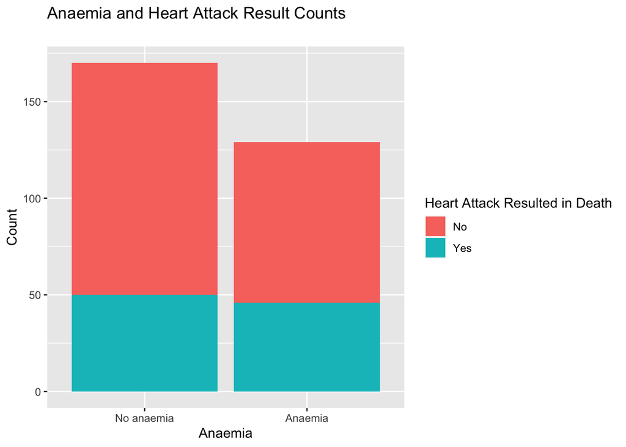

```r
#1.Anaemia and Heart Attack in death
f1 <- ggplot(data,aes(anaemia,fill = DEATH_EVENT))+
  geom_bar()+
  labs(title = "Anaemia and Heart Attack Result Counts\n",
     y = "Count",
     x = "Anaemia")+
  theme(legend.position = "right")+
  scale_fill_discrete(name = "Heart Attack Resulted in Death", labels = c("No","Yes"))+
  scale_x_discrete(labels = c("No anaemia","Anaemia"))
f1
```

#### Diabetes and Heart Attack in death

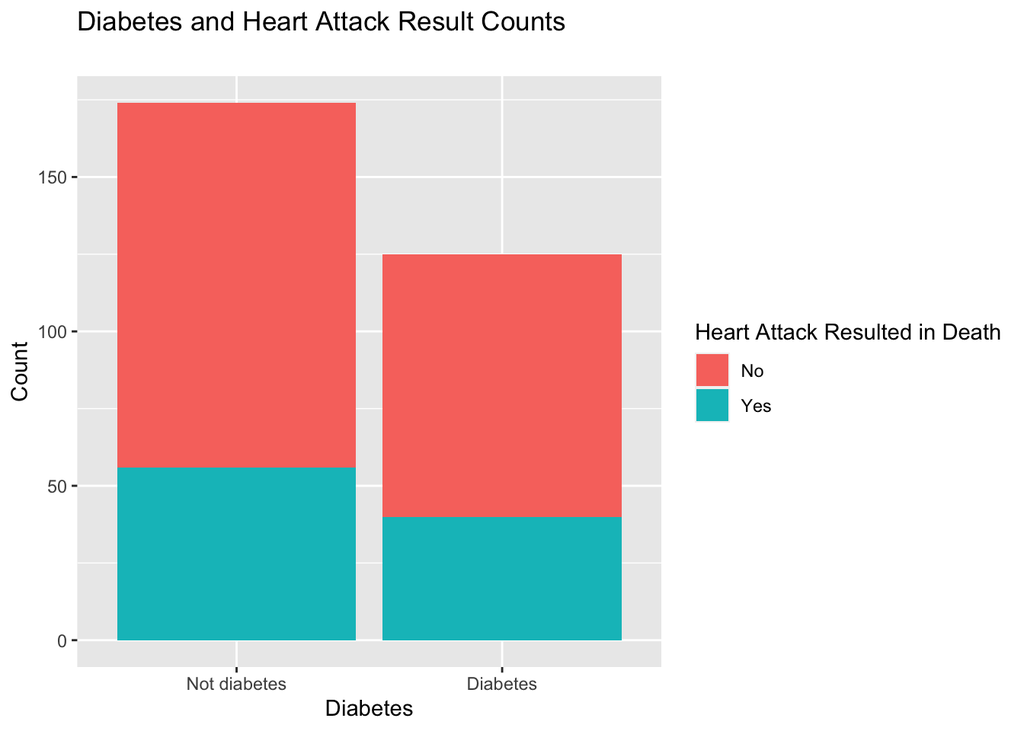

```r
#2.Diabetes and Heart Attack in death
f2 <- ggplot(data,aes(diabetes,fill = DEATH_EVENT))+
  geom_bar()+
  labs(title = "Diabetes and Heart Attack Result Counts\n",
     y = "Count",
     x = "Diabetes")+
  theme(legend.position = "right")+
  scale_fill_discrete(name = "Heart Attack Resulted in Death", labels = c("No","Yes"))+
  scale_x_discrete(labels = c("Not diabetes","Diabetes"))
f2
```

#### High blood pressuere and Heart Attack

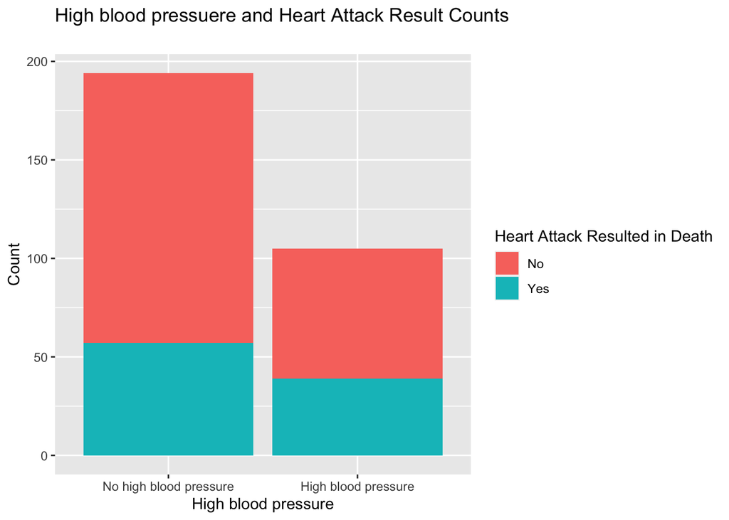

```r
#3.High blood pressuere and Heart Attack in death
f3 <- ggplot(data,aes(high_blood_pressure,fill = DEATH_EVENT))+
  geom_bar()+
  labs(title = "High blood pressuere and Heart Attack Result Counts\n",
     y = "Count", x = "High blood pressure")+
  theme(legend.position = "right")+
  scale_fill_discrete(name = "Heart Attack Resulted in Death", labels = c("No","Yes"))+
  scale_x_discrete(labels = c("No high blood pressure","High blood pressure"))
f3
```

#### Sex and Heart Attack

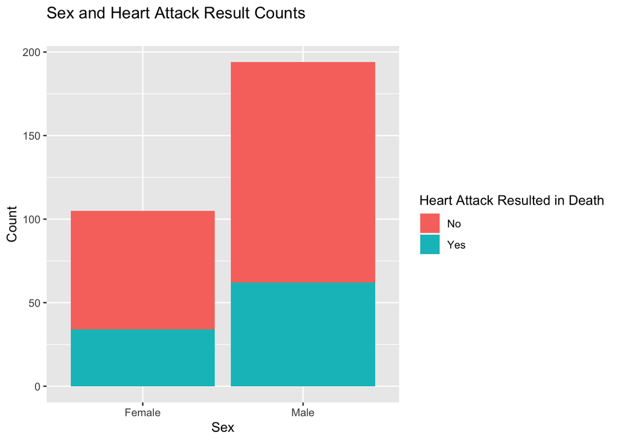

```r
#4.Sex and Heart Attack in death
f4 <- ggplot(data,aes(sex,fill = DEATH_EVENT))+
  geom_bar()+
  labs(title = "Sex and Heart Attack Result Counts\n",
     y = "Count", x = "Sex")+
  theme(legend.position = "right")+
  scale_fill_discrete(name = "Heart Attack Resulted in Death", labels = c("No","Yes"))+
  scale_x_discrete(labels = c("Female","Male"))
f4
```

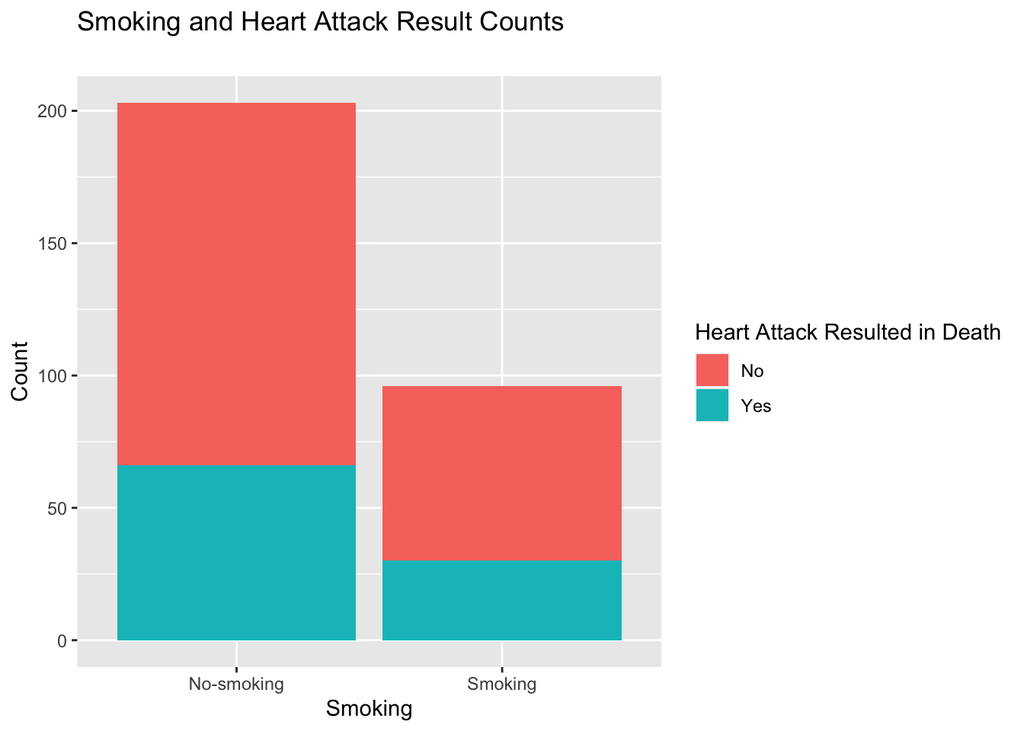

```r
#5.Smoking and Heart Attack in death
f5 <- ggplot(data,aes(smoking,fill = DEATH_EVENT))+
  geom_bar()+
  labs(title = "Smoking and Heart Attack Result Counts\n",
     y = "Count",
     x = "Smoking")+
  theme(legend.position = "right")+
  scale_fill_discrete(name = "Heart Attack Resulted in Death", labels = c("No","Yes"))+
  scale_x_discrete(labels = c("No-smoking","Smoking"))
f5
```

### Distribution of numeric variables

#### Age and heart attack in death

As the age goes up from 60, the total death event increase.

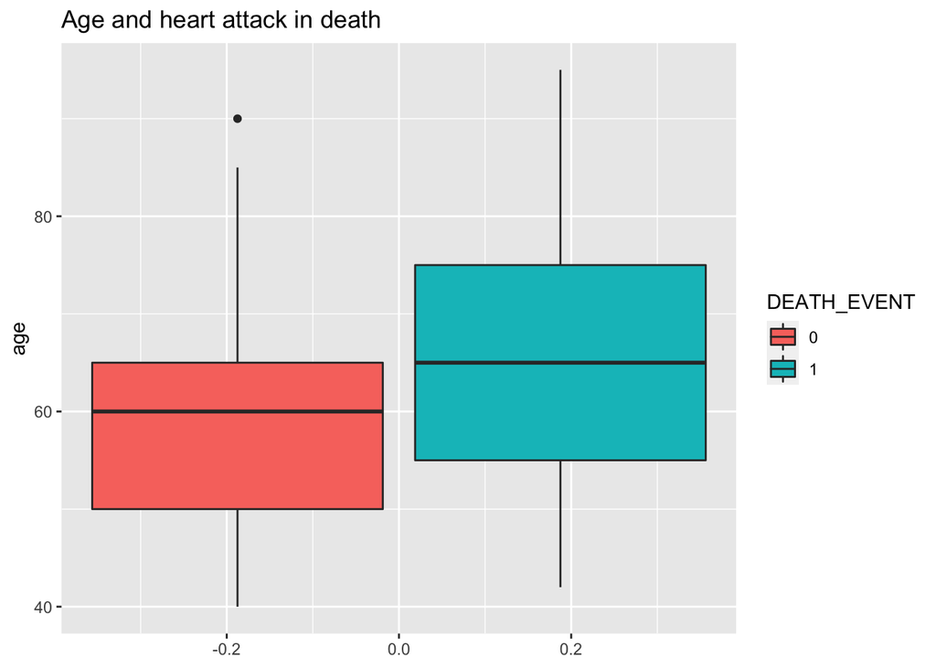

```r
#6.Age and heart attack in death
f6 <- data %>%
  select(age, DEATH_EVENT) %>%
  ggplot(aes(x = age, fill = DEATH_EVENT)) +
  geom_boxplot(show.legend = TRUE) +
  coord_flip() +
  theme(legend.position = "right")+
  ggtitle("Age and heart attack in death")
f6
```

```r
summary(data$age)
```

```
##    Min. 1st Qu.  Median    Mean 3rd Qu.    Max.
##   40.00   51.00   60.00   60.83   70.00   95.00
```

#### Creatinine phosphokinase and heart attack in death

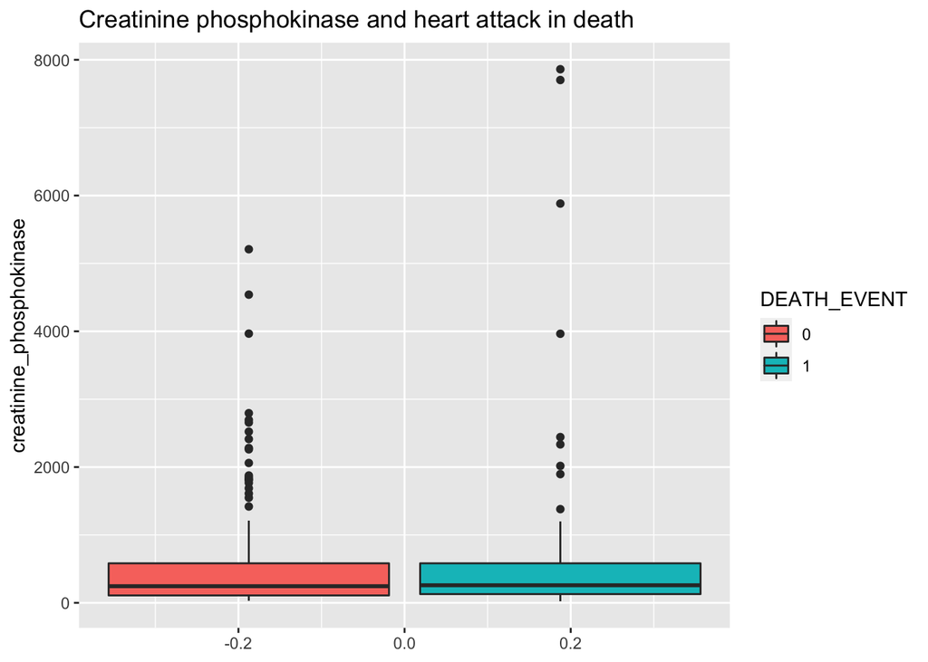

```r
#7. Creatinine phosphokinase and heart attack in death
f7 <- data %>%
  select(creatinine_phosphokinase, DEATH_EVENT) %>%
  ggplot(aes(x = creatinine_phosphokinase, fill = DEATH_EVENT)) +
  geom_boxplot(show.legend = TRUE) +
  coord_flip() +
  theme(legend.position = "right")+
  ggtitle("Creatinine phosphokinase and heart attack in death")
f7
```

```r
summary(data$creatinine_phosphokinase)
```

```
##    Min. 1st Qu.  Median    Mean 3rd Qu.    Max.
##    23.0   116.5   250.0   581.8   582.0  7861.0
```

#### Ejection fraction and heart attack in death

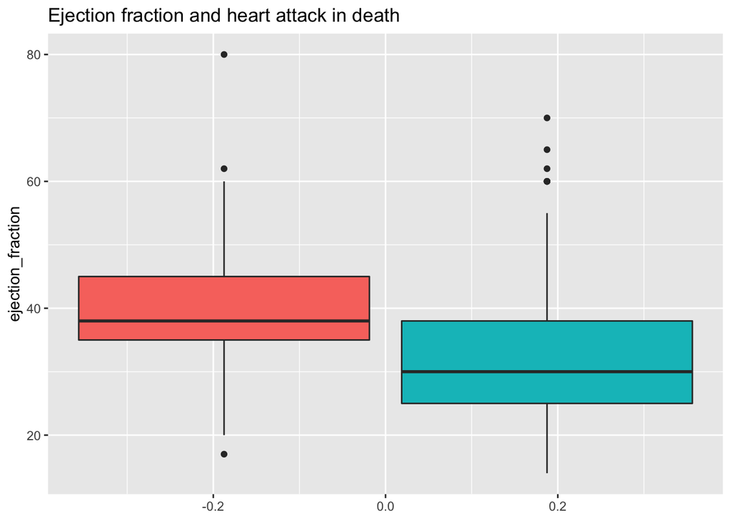

```r
#8.Ejection fraction and heart attack in death
f8 <- data %>%
  select(ejection_fraction, DEATH_EVENT) %>%
  ggplot(aes(x = ejection_fraction, fill = DEATH_EVENT)) +
  geom_boxplot(show.legend = FALSE) +
  coord_flip() +
  theme(legend.position = "right")+
  ggtitle("Ejection fraction and heart attack in death")
f8
```

```r
summary(data$ejection_fraction)
```

```
##    Min. 1st Qu.  Median    Mean 3rd Qu.    Max.
##   14.00   30.00   38.00   38.08   45.00   80.00
```

#### Platelets and heart attack in death

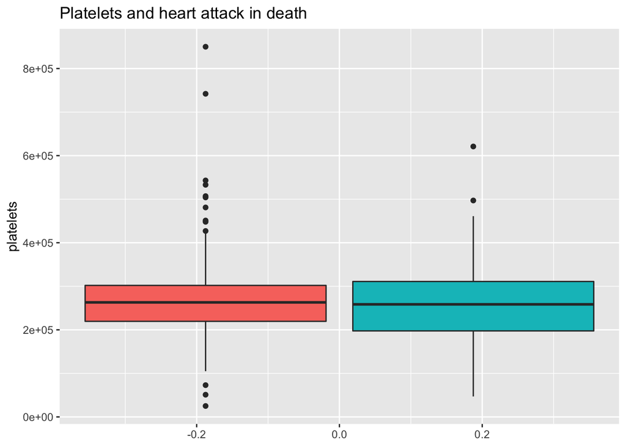

```r
#9.Platelets and heart attack in death
f9 <- data %>%
  select(platelets, DEATH_EVENT) %>%
  ggplot(aes(x = platelets, fill = DEATH_EVENT)) +
  geom_boxplot(show.legend = FALSE) +
  coord_flip() +
  theme(legend.position = "right")+
  ggtitle("Platelets and heart attack in death")
f9
```

```r
summary(data$platelets)
```

```
##    Min. 1st Qu.  Median    Mean 3rd Qu.    Max.
##   25100  212500  262000  263358  303500  850000
```

#### Serum_creatinine and heart attack in death

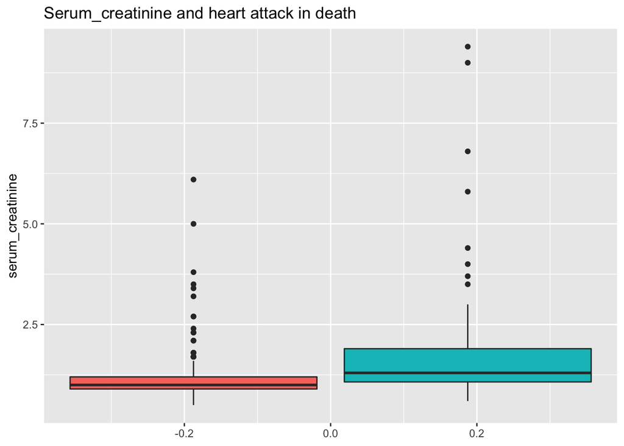

```r
#10.Serum_creatinine and heart attack in death
f10 <- data %>%
  select(serum_creatinine, DEATH_EVENT) %>%
  ggplot(aes(x = serum_creatinine, fill = DEATH_EVENT)) +
  geom_boxplot(show.legend = FALSE) +
  coord_flip() +
  theme(legend.position = "right")+
  ggtitle("Serum_creatinine and heart attack in death")
f10
```

```r
summary(data$serum_creatinine)
```

```
##    Min. 1st Qu.  Median    Mean 3rd Qu.    Max.
##   0.500   0.900   1.100   1.394   1.400   9.400
```

#### Serum sodium and heart attack in death

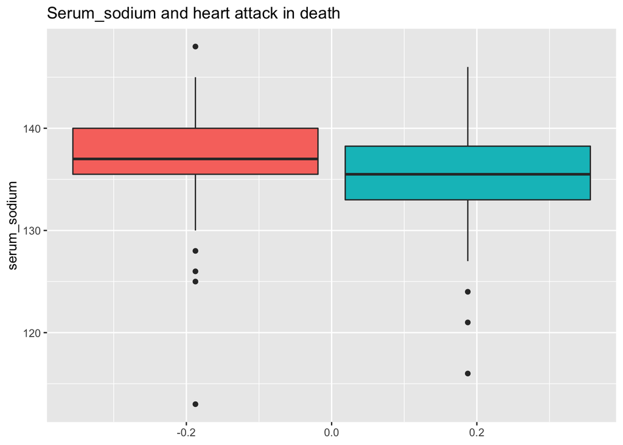

```r
#11.Serum sodium and heart attack in death
p11 <- data %>%
  select(serum_sodium, DEATH_EVENT) %>%
  ggplot(aes(x = serum_sodium, fill = DEATH_EVENT)) +
  geom_boxplot(show.legend = FALSE) +
  coord_flip() +
  theme(legend.position = "right")+
  ggtitle("Serum_sodium and heart attack in death")
p11
```

```r
summary(data$serum_sodium)
```

```
##    Min. 1st Qu.  Median    Mean 3rd Qu.    Max.
##   113.0   134.0   137.0   136.6   140.0   148.0
```

#### Time and heart attack in death

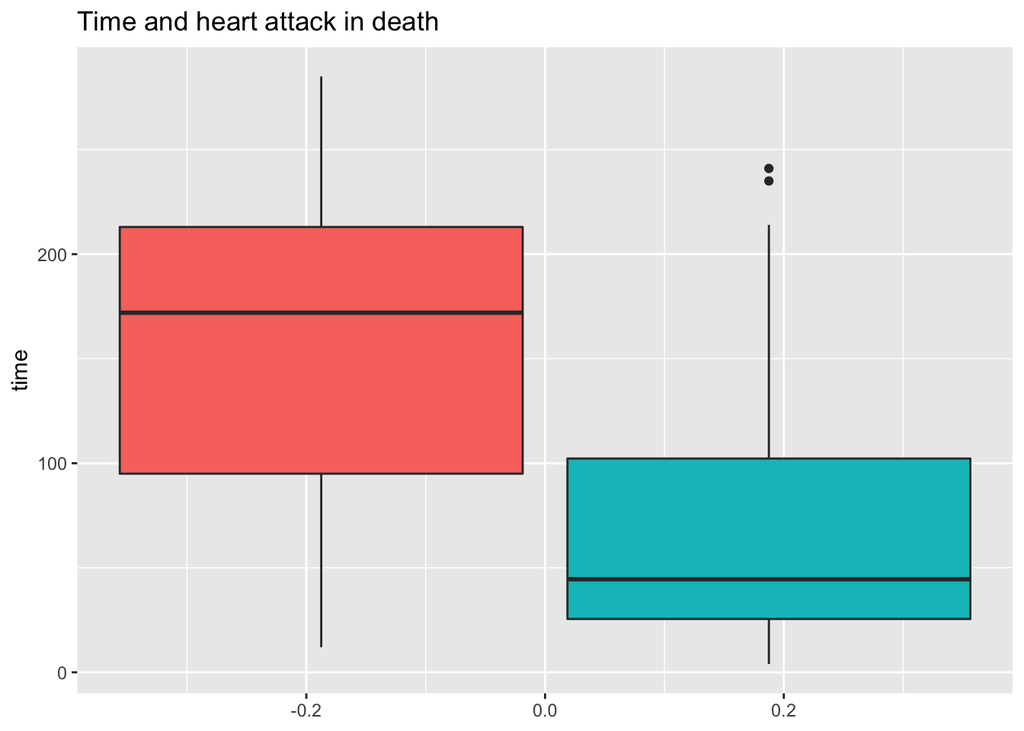

```r
#12.Time and heart attack in death
p12 <- data %>%
  select(time, DEATH_EVENT) %>%
  ggplot(aes(x = time, fill = DEATH_EVENT)) +
  geom_boxplot(show.legend = FALSE) +
  coord_flip() +
  theme(legend.position = "right")+
  ggtitle("Time and heart attack in death")
p12
```

```r
summary(data$time)
```

```
##    Min. 1st Qu.  Median    Mean 3rd Qu.    Max.
##     4.0    73.0   115.0   130.3   203.0   285.0
```

### Correlation of the variables

First, we have to prepare the data for the correlation.

```r
#Prepare for the correlation.
f_features = c("anaemia", "diabetes", "high_blood_pressure", "sex", "smoking", "DEATH_EVENT")

heart_n <- heartd
heartd <- heartd %>%
  mutate_at(f_features, as.factor)
```

We can see the p-value of the variables in the correlation map. We take the p-value which are less than 0.05, as significant parameters. It suggests that we should focus on “age”,“ejection_fraction”, “serum_creatinine”, “serum_sodium” and “time”, for predicting “DEATH_EVENT”.

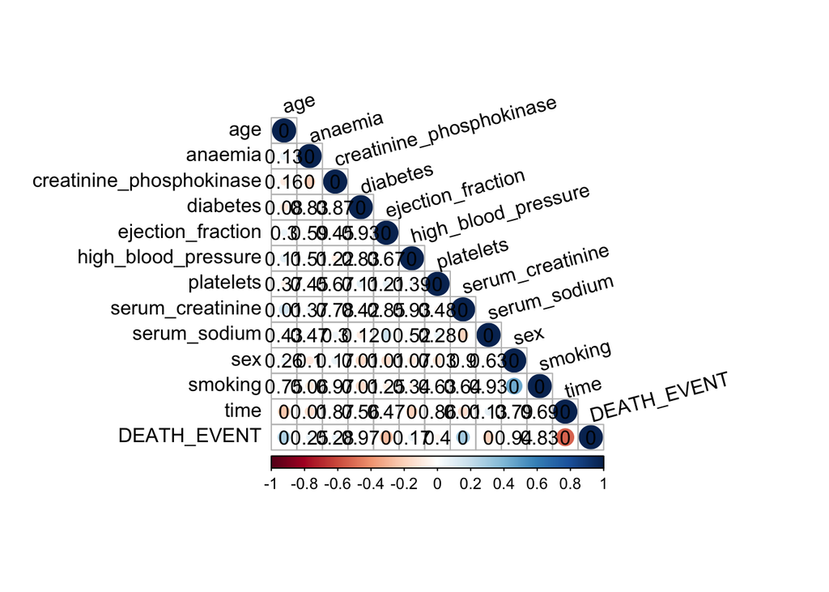

```r
#Use heart_n data
#We can also see the p-value of the variables in the correlation map. We take the p-value which are less than 0.05, as significant parameters. It suggests that we should focus on "age","ejection_fraction", "serum_creatinine", "serum_sodium" and "time", for predicting "DEATH_EVENT".
cor(heart_n) %>%
  corrplot(method = "circle", type = "lower", tl.col = "black", tl.srt = 15,
           p.mat = cor.mtest(heart_n)$p,
           insig = "p-value", sig.level = -1)
```

### Data cleaning

For our modeling of machine learning, we will clean the data. As the previous section suggest, we pick up five variables for the prediction for the death event.

```r
# As we set the DEATH EVENT as the dependent variable, we focus on the five variables as follows; age,ejection_fraction, serum_creatinite, serum_sodium and time.
keep_columns <- c("age","ejection_fraction", "serum_creatinine", "serum_sodium", "time", "DEATH_EVENT")
cleaned_data <- heartd[, keep_columns]

# We are now ready to select a machine learning algorithm to create a prediction
# model for our datasets.
cols <- c("DEATH_EVENT" )
cleaned_data[cols] <- lapply(cleaned_data[cols], factor)
str(cleaned_data)
```

```
## 'data.frame':    299 obs. of  6 variables:
##  $ age              : num  75 55 65 50 65 90 75 60 65 80 ...
##  $ ejection_fraction: int  20 38 20 20 20 40 15 60 65 35 ...
##  $ serum_creatinine : num  1.9 1.1 1.3 1.9 2.7 2.1 1.2 1.1 1.5 9.4 ...
##  $ serum_sodium     : int  130 136 129 137 116 132 137 131 138 133 ...
##  $ time             : int  4 6 7 7 8 8 10 10 10 10 ...
##  $ DEATH_EVENT      : Factor w/ 2 levels "0","1": 2 2 2 2 2 2 2 2 2 2 ...
```

## Modeling

Creating the Training and Testing Sets  
In order to predict heart disease in patients, we will separate the dataset into a training set, as “train_set” and a testing set, “test_set”. To refrain overlearning or learning shortage, we will set 80% for the train set, 20% for the test set.

```r
# We will separate the test set as 20% from the orignal dataset.
set.seed(1980)
index <- createDataPartition(y = data$DEATH_EVENT, times = 1, p = 0.2,
                             list = FALSE)
train_set <- cleaned_data[-index,]
test_set <- cleaned_data[index,]
```

```r
summary(train_set)
```

```
##       age        ejection_fraction serum_creatinine  serum_sodium
##  Min.   :40.00   Min.   :14.00     Min.   :0.500    Min.   :113.0
##  1st Qu.:50.00   1st Qu.:30.00     1st Qu.:0.900    1st Qu.:134.0
##  Median :60.00   Median :38.00     Median :1.100    Median :137.0
##  Mean   :60.56   Mean   :38.09     Mean   :1.398    Mean   :136.6
##  3rd Qu.:69.00   3rd Qu.:45.00     3rd Qu.:1.400    3rd Qu.:140.0
##  Max.   :94.00   Max.   :80.00     Max.   :9.400    Max.   :148.0
##       time       DEATH_EVENT
##  Min.   :  4.0   0:162
##  1st Qu.: 73.0   1: 76
##  Median :120.0
##  Mean   :132.7
##  3rd Qu.:205.8
##  Max.   :285.0
```

### Naive Bayes model

First, we choose Naive Bayes model.

```r
# Train and predict using Naive Bayes
set.seed(1980)
train_nb <- train(DEATH_EVENT ~ ., method = "nb", data = train_set)
y_hat_nb <- predict(train_nb, test_set)
nb_accuracy <- confusionMatrix(data = y_hat_nb, reference = test_set$DEATH_EVENT,
                         positive = NULL)$overall["Accuracy"]
nb_accuracy
```

```
##  Accuracy
## 0.8032787
```

### Decision tree model

Second, we set the decision tree model.

```r
#Train a decision tree model
set.seed(1980)
train_rpart <- train(DEATH_EVENT ~ .,
                     method = "rpart",
                     tuneGrid = data.frame(cp = seq(0, 0.1, len=25)),
                     data = train_set)
#Use best tune code for the optimal results
train_rpart$bestTune
```

|  | cp |
| --- | --- |
| 25 | 0.1 |

```r
#Compute the accuracy of our decision tree model on the testing dataset
dt_accuracy <- confusionMatrix(predict(train_rpart, test_set),
                                  test_set$DEATH_EVENT)$overall["Accuracy"]
dt_accuracy
```

```
##  Accuracy
## 0.8852459
```

### k-Nearest Neigbour Model

Third, we train a k-nearest neighbour algorithm.

```r
set.seed(1980)
train_knn <- train(DEATH_EVENT ~ ., method = "knn",
                   data = train_set,
                   tuneGrid = data.frame(k = seq(2, 30, 2)))
#Use best tune code for the optimal results.
train_knn$bestTune
```

|  | k |
| --- | --- |
| 5 | 10 |

```r
#Compute the accuracy of our knn model on the testing dataset
knn_accuracy <-confusionMatrix(predict(train_knn, test_set, type = "raw"),
                test_set$DEATH_EVENT)$overall["Accuracy"]
knn_accuracy
```

```
##  Accuracy
## 0.8688525
```

### Random Forest Model

Lastly, we try a random forest model for our fourth one.

```r
set.seed(1980)
# Define train control for k-fold (5-fold) cross validation
train_control <- trainControl(method="cv", number=5)
# Train and predict using Random Forest
train_rf <- train(DEATH_EVENT ~ ., data = train_set,
                    method = "rf",
                    trControl = train_control)
y_hat_rf <- predict(train_rf, test_set)
rf_accuracy <- confusionMatrix(data = y_hat_rf, reference = test_set$DEATH_EVENT,
                         positive = NULL)$overall["Accuracy"]
rf_accuracy
```

```
## Accuracy
## 0.852459
```

## Results

We gather the accuracy for each model.

```r
#Results
results <- data_frame(
  Model=c("Model 1: Naive Bayes",
        "Model 2: Decision Tree",
        "Model 3: Knn",
        "Model 4: Random Forest" ),
  Accuracy=c(nb_accuracy, dt_accuracy, knn_accuracy, rf_accuracy))
results
```

| Model | Accuracy |
| --- | --- |
| Model 1: Naive Bayes | 0.8032787 |
| Model 2: Decision Tree | 0.8852459 |
| Model 3: Knn | 0.8688525 |
| Model 4: Random Forest | 0.8524590 |

## References

[1]https://www.kaggle.com/andrewmvd/heart-failure-clinical-data

[2]Irizarry A. Rafael (2018) Introduction to Data Science: Data Analysis and Prediction Algorithms with R.